# Зелимхан Гудиев. Лабораторная №2

2022-10-29

В R деревья решений реализуются с помощью двух основных пакетов: party и rpart. «Случайный лес» реализуется пакетом randomForest.

# Задание 1.

Имеется фрагмент базы данных об анкетировании клиентов турфирмы. Разделите данные на обучающую и тестовую выборки по 70% и 30%, либо используя другие проценты по своему усмотрению.

```r
library(party)
set.seed(1234)

myData <- read.csv("C:/Users/GudievZK/Desktop/GitHub/DF/DataMining/tourism.csv", stringsAsFactors = TRUE)
ind <- sample(2, nrow(myData),
              replace=TRUE,
              prob=c(0.7, 0.3))
trainData <- myData[ind==1,]
testData<- myData[ind==2,]
```

Постройте дерево решений на основе пакета party, выбрав интересующую Вас зависимую переменную. Поясните Ваш выбор. В частности, какую неизвестную информацию об исходных данных позволит получить построение дерева решений для этой переменной? Обозначьте зависимую переменную как Y, и классификационные переменные как Х1, Х2, и т.д., либо другим удобным способом.

```r
myFormula <- EXPENCES ~ LENGTH + TYPE + HOTEL_QUAL + AIM + COMPANIONS + AGE + ORGANIZE
myData_ctree <- ctree(myFormula, data=trainData)
```

**Ответ:**  
*Я выбрал зависимость расходов от длительности пребывания, типа отдыха, качества отеля, компаньонов, возраста и способа организации, чтобы понять какие признаки влияют на величину расходов, и, соответсвенно, как мы можем ориентироваться на более платежеактивных клиентов.*

Приведите матрицу классификации.

```r
table(predict(myData_ctree), trainData$EXPENCES)
```

```
##
##                   20000-35000 35000-50000 less than 20000 over 50000
##   20000-35000              16          12               5          8
##   35000-50000               0           0               0          0
##   less than 20000           0           0               0          0
##   over 50000                0           0               0          0
```

Приведите результаты построения дерева решений в виде таблицы.

```r
print(myData_ctree)
```

```
##
##   Conditional inference tree with 1 terminal nodes
##
## Response:  EXPENCES
## Inputs:  LENGTH, TYPE, HOTEL_QUAL, AIM, COMPANIONS, AGE, ORGANIZE
## Number of observations:  41
##
## 1)*  weights = 41
```

Опишите последовательность проведения классификации с точки зрения переменных. Приведите дерево решений на графике в общем виде.

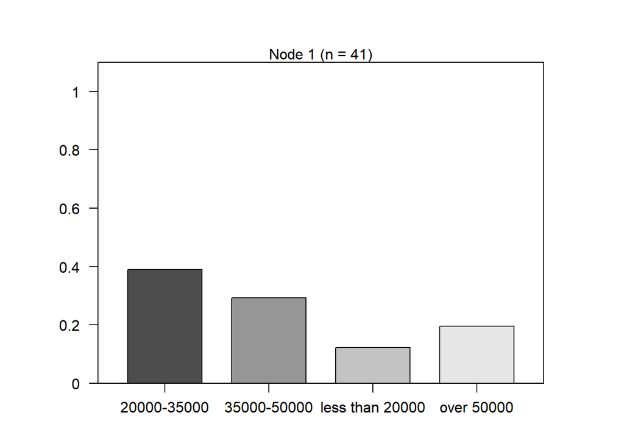

```r
plot(myData_ctree)
```

Приведите дерево решений на графике в упрощенном виде.

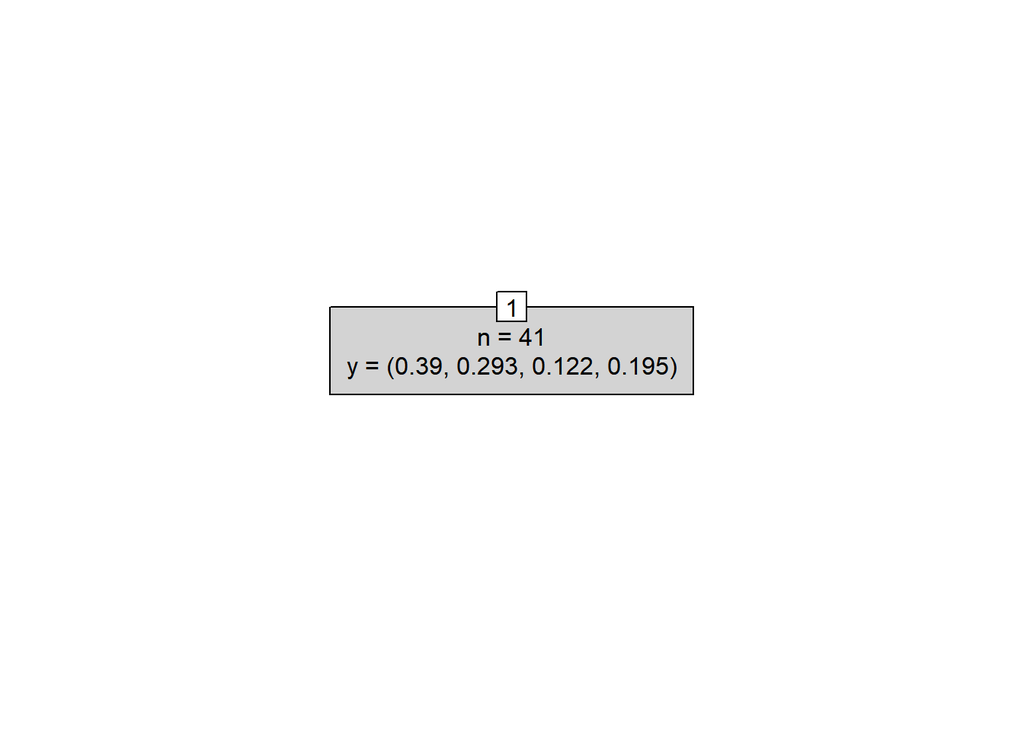

```r
plot(myData_ctree, type="simple")
```

Дайте интерпретацию дерева решений с точки зрения листьев (терминальных узлов). Опишите вероятности для каждого класса результативного признака, указав количество наблюдений в каждом классе, с точки зрения значений параметров классифицирующих признаков. Сведите полученные выводы в небольшую аналитическую записку о результатах классификации.

**Ответ:**  
*Алгоритм не производит построения дерева, останавливаясь на первом шаге.*

# Задание 2.

```r
set.seed(1234)
ind<-sample(2, nrow(myData), replace=TRUE, prob=c(0.8, 0.2))
tourism.train<-myData[ind==1,]
tourism.test<-myData[ind==2,]
library(rpart)
myFormula<- EXPENCES ~ LENGTH + TYPE + HOTEL_QUAL + AIM + COMPANIONS  + ORGANIZE
tourism_rpart<-rpart(myFormula, data=tourism.train,
control=rpart.control(minsplit=5))
```

Приведите результаты построения дерева решений в виде таблицы и графика с подписями.

```r
print(tourism_rpart)
```

```
## n= 43
##
## node), split, n, loss, yval, (yprob)
##       * denotes terminal node
##
##  1) root 43 26 20000-35000 (0.39534884 0.27906977 0.13953488 0.18604651)
##    2) TYPE=Beach,Exotic,Extreme sports,Sightseeing 32 17 20000-35000 (0.46875000 0.25000000 0.06250000 0.21875000)
##      4) AIM=Other,Recreation 23 10 20000-35000 (0.56521739 0.21739130 0.08695652 0.13043478)
##        8) COMPANIONS=Family,Friends,Self 21  8 20000-35000 (0.61904762 0.19047619 0.09523810 0.09523810)
##         16) HOTEL_QUAL=Personnel,Rooms quality 10  2 20000-35000 (0.80000000 0.10000000 0.00000000 0.10000000) *
##         17) HOTEL_QUAL=Placing,Price and services 11  6 20000-35000 (0.45454545 0.27272727 0.18181818 0.09090909)
##           34) COMPANIONS=Friends 4  1 20000-35000 (0.75000000 0.25000000 0.00000000 0.00000000) *
##           35) COMPANIONS=Family,Self 7  5 20000-35000 (0.28571429 0.28571429 0.28571429 0.14285714)
##             70) ORGANIZE=All-inclusive 3  1 20000-35000 (0.66666667 0.00000000 0.33333333 0.00000000) *
##             71) ORGANIZE=Partly by touring company,Self 4  2 35000-50000 (0.00000000 0.50000000 0.25000000 0.25000000) *
##        9) COMPANIONS=Partner 2  1 35000-50000 (0.00000000 0.50000000 0.00000000 0.50000000) *
##      5) AIM=Internship,Study 9  5 over 50000 (0.22222222 0.33333333 0.00000000 0.44444444)
##       10) ORGANIZE=All-inclusive 3  1 35000-50000 (0.33333333 0.66666667 0.00000000 0.00000000) *
##       11) ORGANIZE=Partly by touring company,Self 6  2 over 50000 (0.16666667 0.16666667 0.00000000 0.66666667) *
##    3) TYPE=Cruise,Curative,Mountain skiing 11  7 35000-50000 (0.18181818 0.36363636 0.36363636 0.09090909)
##      6) HOTEL_QUAL=Placing,Price and services 7  3 less than 20000 (0.28571429 0.14285714 0.57142857 0.00000000)
##       12) ORGANIZE=All-inclusive,Partly by touring company 5  3 20000-35000 (0.40000000 0.20000000 0.40000000 0.00000000)
##         24) TYPE=Mountain skiing 2  0 20000-35000 (1.00000000 0.00000000 0.00000000 0.00000000) *
##         25) TYPE=Cruise,Curative 3  1 less than 20000 (0.00000000 0.33333333 0.66666667 0.00000000) *
##       13) ORGANIZE=Self 2  0 less than 20000 (0.00000000 0.00000000 1.00000000 0.00000000) *
##      7) HOTEL_QUAL=Personnel,Rooms quality 4  1 35000-50000 (0.00000000 0.75000000 0.00000000 0.25000000) *
```

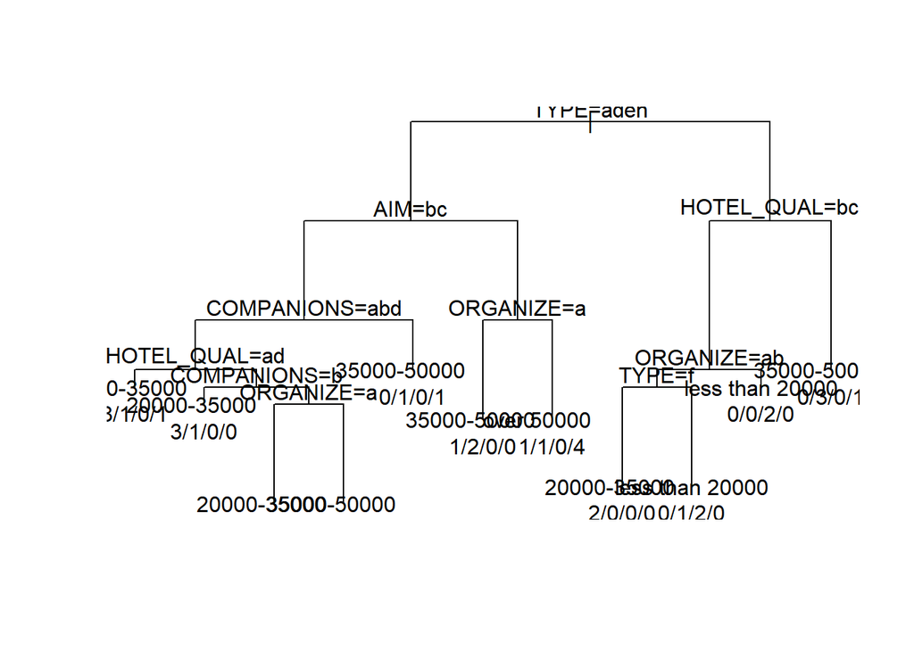

```r
plot(tourism_rpart)
text(tourism_rpart, use.n=T)
```

Приведите таблицу с построенными деревьями, в которой указаны ошибки классификации.

```r
print(tourism_rpart$cptable)
```

```
##           CP nsplit rel error   xerror      xstd
## 1 0.09615385      0 1.0000000 1.000000 0.1233115
## 2 0.07692308      2 0.8076923 1.269231 0.1065490
## 3 0.03846154      4 0.6538462 1.269231 0.1065490
## 4 0.02564103      7 0.5384615 1.269231 0.1065490
## 5 0.01000000     10 0.4615385 1.269231 0.1065490
```

Приведите дерево с наименьшим количеством ошибок классификации в виде таблицы и графика с подписями.

```r
opt<-which.min(tourism_rpart$cptable[, "xerror"])
cp<-tourism_rpart$cptable[opt, "CP"]
tourism_prune<-prune(tourism_rpart, cp=cp)
print(tourism_prune)
```

```
## n= 43
##
## node), split, n, loss, yval, (yprob)
##       * denotes terminal node
##
## 1) root 43 26 20000-35000 (0.3953488 0.2790698 0.1395349 0.1860465) *
```

```r
# plot(tourism_prune)
# text(tourism_prune, use.n=T)
```

Приведите точечный график результатов классификации. Сделайте выводы о подгонке модели классификации с точки зрения расположения точек на графике.

```r
# поскольку стрижка дерева бессмысленна, то оставляем полную модель tourism_rpart
Ytourism_pred <- predict(tourism_rpart #tourism_prune
                         , newdata=tourism.test)
print(Ytourism_pred)
```

```
##    20000-35000 35000-50000 less than 20000 over 50000
## 5    0.7500000   0.2500000       0.0000000  0.0000000
## 14   0.8000000   0.1000000       0.0000000  0.1000000
## 16   0.0000000   0.5000000       0.0000000  0.5000000
## 26   0.3333333   0.6666667       0.0000000  0.0000000
## 28   0.1666667   0.1666667       0.0000000  0.6666667
## 29   0.1666667   0.1666667       0.0000000  0.6666667
## 39   0.0000000   0.3333333       0.6666667  0.0000000
## 40   0.0000000   0.5000000       0.0000000  0.5000000
```

```r
# xlim<-range(myData$EXPENCES)
# plot(Ytourism_pred~EXPENCES, data=tourism.test, xlab="Факт", ylab="Классификация",
# ylim=xlim, xlim=xlim)
# abline(a=0, b=1)
```

**Ответ:**  
*Непонятно как построить этот график для задачи классификации категориальной переменной, когда предсказанием является вектор вероятностей принадлежности наблюдения к определенному классу.*

# Задание 3.

Имеются данные о заявлениях на выдачу кредита. Какие из этих переменных количественные? Какие качественные? Какие из исходных переменных дискретные? Какие непрерывные? Какие из исходных переменных номинальные? Какие порядковые? Разделите данные на обучающую выборку (Train) и на данные, которые необходимо верифицировать (Verify), предварительно рассортировав таблицу.

**Ответ:**  
*Отсутствует датасет с необходимыми данными. Есть два уже разделенных датасета ‘credit applications train.csv’ и ‘credit applications test.csv’, но в них отсутствуют названия колонок.*  
*Также не удается прочитать файлы credit `applications train.csv` и `credit applications test.csv` - все методы выдают ошибку. Например, read.csv выдает:*  
Error in make.names(col.names, unique = TRUE) : invalid multibyte string at ‘’

*Поэтому закомментируем оставшийся код.*